# **DIFFERENTIAL GENE EXPRESSION (RNASeq)** **PIPELINE DOCUMENTATION**

Author: Walter Odur Affiliation: ACE-Uganda

September 11, 2024

# **Background**

RNA-seq (RNA sequencing) quantifies gene expression through next-generation sequencing. This pipeline analyzes differential expression between two experimental conditions using human genome data. Given the computational demands, we recommend running this analysis on a high-performance computing (HPC) cluster for adequate RAM and processing power.

## Sample Acquisition

The human samples were acquired from a research project entitled *TBC1 domain-containing proteins are frequently involved in triple-negative breast cancers in connection with the induction of a glycolytic phenotype* which was conducted by Lupi *et al*., 2024  
The study investigated the role of TBC1 domain-containing proteins (TBC1Ds) in triple-negative breast cancer (TNBC), emphasizing their involvement in glycolytic metabolism.  
TNBC is a breast cancer subtype known for poor prognosis and high clinical heterogeneity.  
The study highlighted how TBC1Ds, traditionally known as regulators of RAB GTPases and membrane trafficking, are overexpressed in TNBC and influence cancer aggressiveness by promoting glycolysis.

**Some of the key findings from the study underscored the following:**

1. Elevated Expression in TNBC: Several TBC1D genes are overexpressed in TNBC compared to other breast cancer subtypes, correlating with poor patient outcomes.
2. Metabolic Reprogramming: TBC1Ds contribute to the Warburg effect (increased aerobic glycolysis), which is central to cancer cell survival and proliferation.
3. Key Drivers of Glycolysis: Genes like TBC1D7, TBC1D22B, and TBC1D31 are identified as critical in maintaining a glycolytic phenotype in TNBC cell lines. Their depletion reduces lactate production and metabolic activity.
4. TBC1D7 as a Prognostic Marker: TBC1D7 overexpression predicts poor prognosis and stratifies TNBC patients into distinct risk groups, aiding in potential therapeutic decision-making.
5. Mechanistic Insights: TBC1D7’s role in glycolysis is independent of its known interaction with the mTORC1 pathway, involving alternative mechanisms such as the transcriptional regulation of glycolytic enzymes and glucose transporter GLUT1.

**Clinical Implications:**

- Biomarkers: TBC1Ds, particularly TBC1D7, could serve as biomarkers for prognosis in TNBC.
- Therapeutic Targets: The findings suggest targeting TBC1Ds and the glycolytic pathways they regulate as potential strategies for TNBC treatment.

The following *study Questions* guided the researchers to have deeper exploration into the molecular mechanisms, therapeutic opportunities, and clinical applications associated with TBC1Ds in TNBC:

**Biomolecular and Functional Role of TBC1Ds:**

a). What mechanisms underlie the role of TBC1Ds in promoting glycolysis in TNBC?  
b). How do alterations in membrane trafficking pathways contribute to metabolic changes in TNBC?

**Subtype-Specific Analysis:**

a). How do the metabolic profiles of TNBC subtypes differ with variations in TBC1D expression?  
b). What are the implications of TBC1D-driven metabolic heterogeneity on therapy resistance?

**Therapeutic Development:**

a). Could inhibition of TBC1Ds alter the tumor microenvironment or immune responses in TNBC?  
b). What are the effects of combining TBC1D inhibition with existing glycolysis-targeting drugs?

**Prognostic Value and Patient Stratification:**

a). How robust is the prognostic utility of TBC1D7 across diverse TNBC cohorts?  
b). Can TBC1D7 expression levels be used to tailor patient-specific therapeutic regimens?

**Comparative Omics Insights:**

a). How do transcriptomic and metabolomic profiles of TBC1D-overexpressing TNBC compare to other cancer subtypes?  
What other metabolic pathways are altered by TBC1D activity beyond glycolysis?

## **The Pipeline**

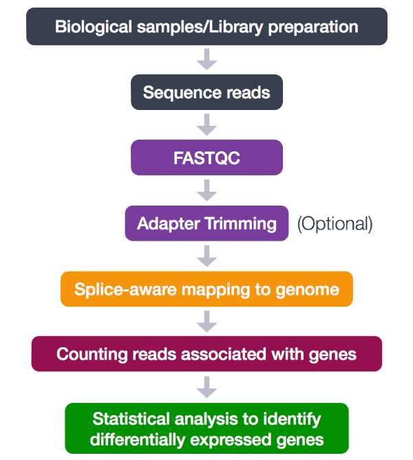

This shows the typical analysis steps from sample acquisition to statistical analysis